# MODULE 1. Predicting Heart Attack. A Complete Machine Lerning Project Using R and Caret

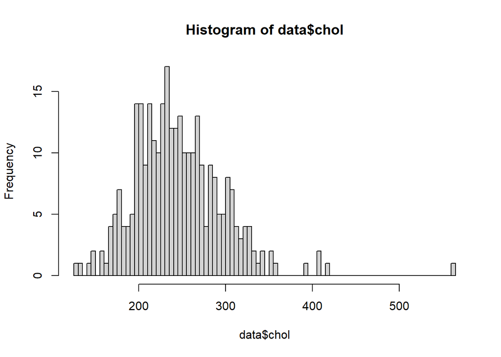

```r
hist(data$chol, 100)
```

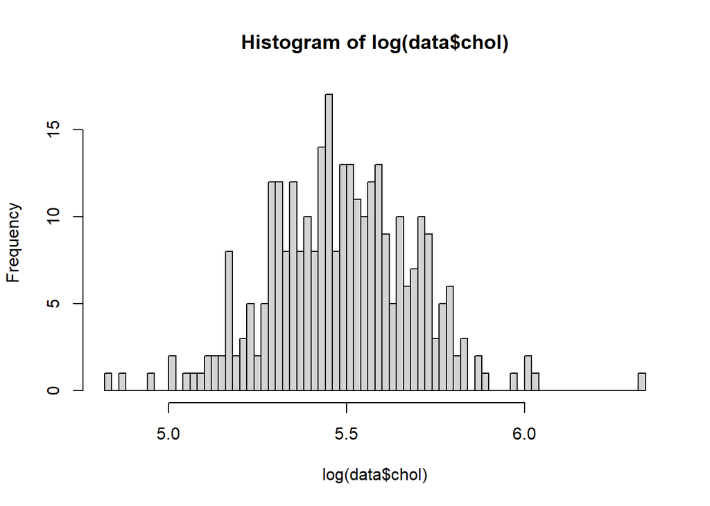

```r
hist(log(data$chol), 100)
```

```r
library(forecast)
```

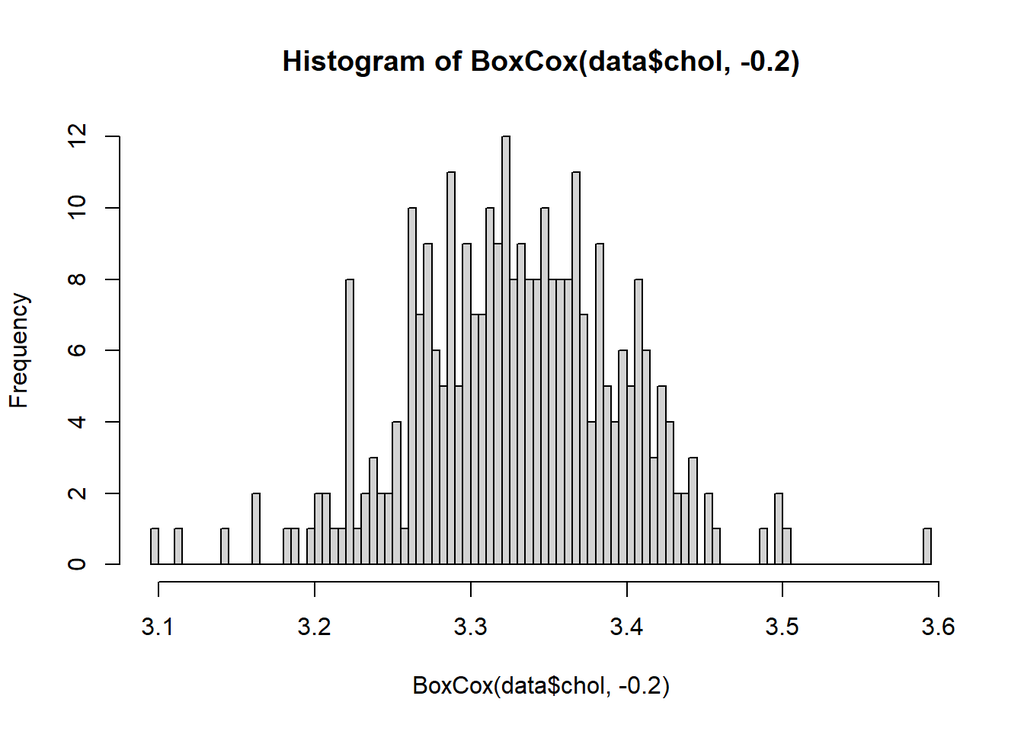

```r
hist(BoxCox(data$chol, -0.2), 100)
```

## 6.2 Features engineering

Data preprocessing encompasses those transformations of the data made in order that they can be accepted by the machine learning algorithm or that improve their results. All preprocessing of data must be learned from training observations and then applied to the training set and the test set. This is very important so as not to violate the condition that no information from test observations can participate in or influence the fit of the model. Although it is not possible to create a single listing, some preprocessing steps that are most often applied in practice are:

- Imputation of missing values
- Exclusion of variables with variance close to zero
- Dimensionality reduction
- Standardization of numerical variables
- Binarization of qualitative variables

The idea behind this package is as follows:

1. Define which is the response variable, the predictors and the training data set, `recipe ()`.
2. Define all the transformations (scaling, selection, filtering …) that you want to apply, `%>% step _ ()`.
3. Learn the necessary parameters for these transformations with the training observations `prep ()`.
4. Apply the learned transformations to any `bake ()` dataset.

In the following sections, all the preprocessing steps are stored in a recipe object and finally applied to the data.

## 6.3 Imputation of missing values

As identified in the data several variables contain missing values. The vast majority of algorithms do not accept incomplete observations, so when the data set contains missing values, you can:

- Delete those observations that are incomplete.
- Delete those variables that contain missing values.
- Try to estimate the missing values using the rest of the available information (imputation).

The first two options, although simple, involve losing information. Deletion of observations can only be applied when many are available and the percentage of incomplete records is very low. In the case of eliminating variables, the impact will depend on how much information these variables contribute to the model.

When imputation is used, it is very important to take into account the risk involved when entering values in predictors that have a lot of influence on the model. Suppose a medical study in which, when one of the predictors is positive, the model almost always predicts that the patient is healthy. For a patient whose value of this predictor is unknown, the risk that the imputation is wrong is very high, so it is preferable to obtain a prediction based only on the available information. This is another example of the importance of the analyst knowing the problem he is facing and thus making the best decision.

In this data set, we only have 7 missing values so they could be removed. However, we decide to impute those values.

```r
sum(is.na(data))
```

```
## [1] 7
```

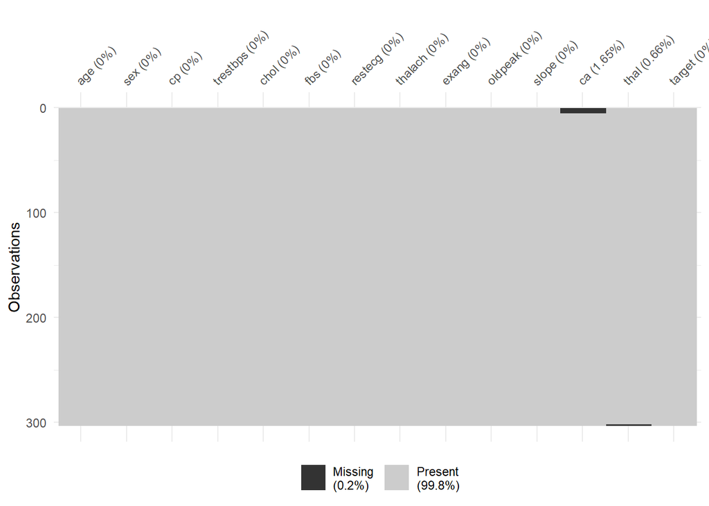

```r
library(visdat)
vis_miss(data, cluster = TRUE)
```

If a variable is absent for ~80% of the observations, with such a high percentage of absent values, it is not convenient to impute it, it is excluded directly from the model.

Imputation is a complex process that must be carried out carefully, carefully identifying which variables are appropriate for each imputation. For more details on why they are carried out as follows, see Annex 7.

The recipes package allows 4 different imputation methods:

- `step_meanimpute ()`: mean imputation via the predictor (continuous predictors).
- `step_modeimpute ()`: imputation via predictor mode (qualitative predictors).
- `step_bagimpute ()`: imputation via Bagged Trees.
- `step_knnimpute ()`: imputation via K-Nearest Neighbors.

Also noteworthy are the Hmisc missForest and MICE packages that allow other methods to be applied.

```r
library(recipes)

# 1
colnames(datos_train)
```

```
##  [1] "age"      "sex"      "cp"       "trestbps" "chol"     "fbs"
##  [7] "restecg"  "thalach"  "exang"    "oldpeak"  "slope"    "ca"
## [13] "thal"     "target"
```

```r
objeto_recipe <- recipe(target ~ ., data = datos_train)
objeto_recipe
```

```
## Data Recipe
##
## Inputs:
##
##       role #variables
##    outcome          1
##  predictor         13
```

```r
# 2

objeto_recipe <- objeto_recipe %>% step_meanimpute(all_numeric())

objeto_recipe
```

```
## Data Recipe
##
## Inputs:
##
##       role #variables
##    outcome          1
##  predictor         13
##
## Operations:
##
## Mean Imputation for all_numeric()
```

```r
# 3

trained_recipe <- prep(objeto_recipe, training = datos_train)
trained_recipe
```

```
## Data Recipe
##
## Inputs:
##
##       role #variables
##    outcome          1
##  predictor         13
##
## Training data contained 244 data points and 5 incomplete rows.
##
## Operations:
##
## Mean Imputation for age, trestbps, chol, thalach, oldpeak, ca [trained]
```

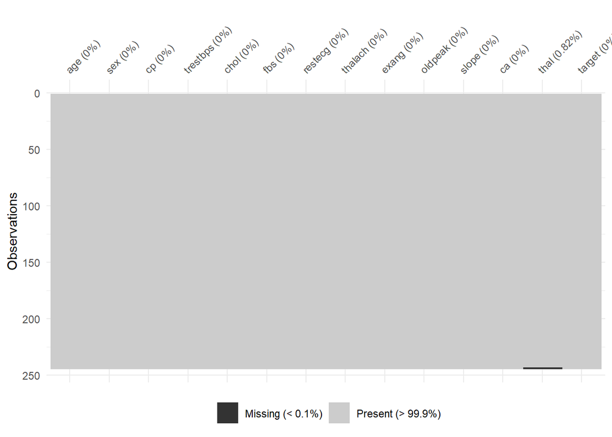

```r
datos_train_prep <- bake(trained_recipe, new_data = datos_train)
datos_test_prep <- bake(trained_recipe, new_data = datos_test)

vis_miss(datos_train_prep, cluster = T)
```

## 6.4 Variables with variance close to zero

Predictors that contain a single value (zero-variance) should not be included in the model since they do not provide information. It is also not convenient to include predictors that have a variance close to zero, that is, predictors that take only a few values, some of which appear very infrequently. The problem with the latter is that they can become predictors with zero variance when dividing observations by cross-validation or bootstrapping.

The nearZeroVar () function in the caret package and step_nzv () in the recipe package identify potentially problematic predictors as those that have a single value (zero variance) or that meet the following two conditions:

- Frequency ratio: ratio between the frequency of the most common value and the frequency of the second most common value. This ratio tends to 1 if the frequencies are equally distributed and to large values when the frequency of the majority value is much higher than the rest (the denominator is a small decimal number). Default value freqCut = 95/5.
- Percentage of unique values: number of unique values divided by the total number of samples (multiplied by 100). This percentage approaches zero the greater the variety of values. Default value uniqueCut = 10.

```r
library(caret)
data  %>% nearZeroVar(saveMetrics = TRUE)
```

|  | freqRatio | percentUnique | zeroVar | nzv |
| --- | --- | --- | --- | --- |
| age | 1.117647 | 13.531353 | FALSE | FALSE |
| sex | 2.156250 | 0.660066 | FALSE | FALSE |
| cp | 1.643678 | 1.320132 | FALSE | FALSE |
| trestbps | 1.027778 | 16.171617 | FALSE | FALSE |
| chol | 1.000000 | 50.165017 | FALSE | FALSE |
| fbs | 5.733333 | 0.660066 | FALSE | FALSE |
| restecg | 1.034014 | 0.990099 | FALSE | FALSE |
| thalach | 1.222222 | 30.033003 | FALSE | FALSE |
| exang | 2.060606 | 0.660066 | FALSE | FALSE |
| oldpeak | 5.823529 | 13.201320 | FALSE | FALSE |

[output cut: 4 more lines]

```r
objeto_recipe <- objeto_recipe %>% step_nzv(all_predictors())

objeto_recipe
```

```
## Data Recipe
##
## Inputs:
##
##       role #variables
##    outcome          1
##  predictor         13
##
## Operations:
##
## Mean Imputation for all_numeric()
## Sparse, unbalanced variable filter on all_predictors()
```

## 6.5 Standardization and scaling

When the predictors are numerical, the scale on which they are measured, as well as the magnitude of their variance, can greatly influence the model. Many machine learning algorithms (SVM, neural networks, lasso …) are sensitive to this, so that if the predictors are not somehow equalized, those that are measured on a larger scale or have more variance will dominate the model. although they are not the ones that have the most relationship with the response variable. There are mainly 2 strategies to avoid it:

- Centered: it consists of subtracting from each value the mean of the predictor to which it belongs. If the data is stored in a dataframe, the centering is achieved by subtracting from each value the mean of the column in which it is located. As a result of this transformation, all predictors have a mean of zero, that is, the values are centered around the origin.
- Normalization (standardization): consists of transforming the data so that all the predictors are approximately on the same scale. There are two ways to achieve this:
  - Z-score normalization: divide each predictor by its standard deviation after it has been centered, in this way, the data has a normal distribution. $ z = (x- mu) / sigma $
  - Max-min standardization: transform the data so that they are within the range [0, 1]. $ (X-Xmin) / (Xmax-Xmin) $

For this analysis, all numerical variables are normalized.

```r
objeto_recipe <- objeto_recipe %>% step_center(all_numeric())
objeto_recipe <- objeto_recipe %>% step_scale(all_numeric())
objeto_recipe
```

```
## Data Recipe
##
## Inputs:
##
##       role #variables
##    outcome          1
##  predictor         13
##
## Operations:
##
## Mean Imputation for all_numeric()
## Sparse, unbalanced variable filter on all_predictors()
## Centering for all_numeric()
## Scaling for all_numeric()
```

## 6.6 Binarization of qualitative variables

Binarization consists of creating new dummy variables with each of the levels of the qualitative variables. This process is also known as one hot encoding. For example, a variable called color containing the red, green, and blue levels will become three new variables (color_red, color_green, color_blue), all with the value 0 except the one that matches the observation, which takes the value 1.

By default, the step_dummy (all_nominal ()) function binarizes all stored variables as factor or character type. In addition, it eliminates one of the levels to avoid redundancies. Going back to the previous example, it is not necessary to store all three variables, since if color_red and color_green take the value 0, the variable color_blue necessarily takes the value 1. If color_red or color_green take the value 1, then color_blue is necessarily 0.

```r
objeto_recipe <- objeto_recipe %>% step_dummy(all_nominal(), -all_outcomes())

# objeto_recipe <- objeto_recipe %>% step_dummy(all_nominal(), -all_outcomes(), one_hot = T)
objeto_recipe
```

```
## Data Recipe
##
## Inputs:
##
##       role #variables
##    outcome          1
##  predictor         13
##
## Operations:
##
## Mean Imputation for all_numeric()
## Sparse, unbalanced variable filter on all_predictors()
## Centering for all_numeric()
## Scaling for all_numeric()
## Dummy variables from all_nominal(), -all_outcomes()
```

Once the recipe object has been created with all the preprocessing transformations, they are learned with the training data and applied to the two sets.

```r
trained_recipe <- prep(objeto_recipe, training = datos_train)
trained_recipe
```

```
## Data Recipe
##
## Inputs:
##
##       role #variables
##    outcome          1
##  predictor         13
##
## Training data contained 244 data points and 5 incomplete rows.
##
## Operations:
##
## Mean Imputation for age, trestbps, chol, thalach, oldpeak, ca [trained]
## Sparse, unbalanced variable filter removed no terms [trained]
## Centering for age, trestbps, chol, thalach, oldpeak, ca [trained]
## Scaling for age, trestbps, chol, thalach, oldpeak, ca [trained]
## Dummy variables from sex, cp, fbs, restecg, exang, slope, thal [trained]
```

```r
datos_train_prep <- bake(trained_recipe, new_data = datos_train)
datos_test_prep <- bake(trained_recipe, new_data = datos_test)

sd(datos_train_prep$age)
```

```
## [1] 1
```

```r
glimpse(datos_train_prep)
```

```
## Rows: 244
## Columns: 19
## $ age                    <dbl> 0.94026156, -1.90836276, -1.47011287, 0.1733...
## $ trestbps               <dbl> 0.75231897, -0.09595196, -0.09595196, -0.661...
## $ chol                   <dbl> -0.24066196, 0.07414908, -0.77769256, -0.185...
## $ thalach                <dbl> 0.009606593, 1.615686552, 0.964573055, 1.225...
## $ oldpeak                <dbl> 1.11168228, 2.14996161, 0.33297278, -0.18616...
## $ ca                     <dbl> -0.7247688, -0.7247688, -0.7247688, -0.72476...
## $ target                 <fct> No, No, No, No, No, No, No, No, No, No, No, ...
## $ sex_Male               <dbl> 1, 1, 0, 1, 0, 1, 1, 1, 1, 1, 0, 1, 0, 0, 0,...
## $ cp_Atypical.angina     <dbl> 0, 0, 1, 1, 0, 0, 1, 0, 0, 0, 0, 1, 0, 0, 0,...
## $ cp_No.angina           <dbl> 0, 1, 0, 0, 0, 0, 0, 1, 1, 0, 1, 0, 0, 1, 1,...
## $ cp_Typical.angina      <dbl> 1, 0, 0, 0, 0, 0, 0, 0, 0, 0, 0, 0, 1, 0, 0,...
## $ fbs_Yes                <dbl> 1, 0, 0, 0, 0, 0, 0, 1, 0, 0, 0, 0, 1, 0, 0,...
## $ restecg_Normal         <dbl> 0, 1, 0, 1, 1, 1, 1, 1, 1, 1, 1, 1, 0, 1, 1,...
## $ restecg_Abnormalities  <dbl> 0, 0, 0, 0, 0, 0, 0, 0, 0, 0, 0, 0, 0, 0, 0,...
## $ exang_Yes              <dbl> 0, 0, 0, 0, 1, 0, 0, 0, 0, 0, 0, 0, 0, 0, 0,...
## $ slope_Flat             <dbl> 0, 0, 0, 0, 0, 1, 0, 0, 0, 0, 0, 0, 0, 1, 0,...
## $ slope_Ascending        <dbl> 0, 0, 1, 1, 1, 0, 1, 1, 1, 1, 1, 1, 1, 0, 1,...
## $ thal_Normal.flow       <dbl> 0, 1, 1, 1, 1, 0, 0, 0, 1, 1, 1, 1, 1, 1, 1,...
## $ thal_Reversible.defect <dbl> 0, 0, 0, 0, 0, 0, 1, 1, 0, 0, 0, 0, 0, 0, 0,...
```

# 7 Creation of a predictive model

## 7.1 Recap

```r
set.seed(123)
split_strat  <- initial_split(data, prop = 0.8, strata = "target")
datos_train  <- training(split_strat)
datos_test   <- testing(split_strat)

objeto_recipe <- recipe(target ~ ., data = datos_train) %>%
  step_knnimpute(all_predictors()) %>%
  step_nzv(all_predictors()) %>%
  step_center(all_numeric()) %>%
  step_scale(all_numeric()) %>%
  step_dummy(all_nominal(), -all_outcomes())

trained_recipe <- prep(objeto_recipe, training = datos_train)

datos_train_prep <- bake(trained_recipe, new_data = datos_train)
datos_test_prep <- bake(trained_recipe, new_data = datos_test)
```

Once the data has been preprocessed and the predictors selected, the next step is to use a machine learning algorithm that allows creating a model capable of representing the patterns present in the training data and generalizing them to new observations. Finding the best model is not easy, there are many algorithms, each with its own characteristics and with different parameters that must be adjusted. In general, the steps followed to obtain a good model are:

1. **Adjustment / training**: consists of applying a machine learning algorithm to the training data so that the model learns.
2. **Evaluation / Validation**: The goal of a predictive model is not to be able to predict observations that are already known, but new observations that the model has not seen. In order to estimate the error that a model makes, it is necessary to resort to validation strategies, among which stand out test set, bootstrap and cross validation.
3. **Optimization of hyperparameters**: many machine learning algorithms contain in their equations one or more parameters that are not learned with the data, these are known as hyperparameters. For example, linear SVM has the cost hyperparameter C. There is no way of knowing in advance what the exact value of a hyperparameter is that gives rise to the best model, so validation strategies must be used to compare different values.
4. **Prediction**: Once the model is created, it is used to predict new observations.

It is throughout this process where the features offered by caret stand out the most, allowing the same syntax to be used to adjust, optimize, evaluate and predict a wide range of models, varying only the name of the algorithm. Although caret allows all this with just a few lines of code, there are many arguments that can be adapted, each with multiple possibilities. In order to better expose each of the options, instead of directly creating a final model, examples are shown from least to most complex.

## 7.2 Model training

All models built into the caret package are trained with the train () function. The arguments of this function include:

`formula`: the formula of the model to be created.

`x, y`: Instead of a formula, you can pass the values of the predictors and the response variable separately.

`method`: the name of the algorithm to be used (listing) [http://topepo.github.io/caret/available-models.html].

`metric`: the metrics used to assess the predictive power of the model. By default, accuracy is used for classification problems and RMSE for regression Annex 5.

`trControl`: additional specifications on how to carry out model training.

`...`: arguments specific to the algorithm used.

```r
# ?train

# The resampling method: "boot", "boot632", "optimism_boot", "boot_all", "cv", "repeatedcv", "LOOCV", "LGOCV" (for repeated training/test splits), "none" (only fits one model to the entire training set), "oob" (only for random forest, bagged trees, bagged earth, bagged flexible discriminant analysis, or conditional tree forest models),

control_train <- trainControl(method="cv", number=5, returnResamp="all")

set.seed(123)

modelo_glm <-
  train(target ~ .,
        method = "glmnet",
        family = "binomial",
        trControl = control_train,
        data = datos_train_prep,
        metric = "Accuracy")

summary(modelo_glm)
```

```
##             Length Class      Mode
## a0            79   -none-     numeric
## beta        1422   dgCMatrix  S4
## df            79   -none-     numeric
## dim            2   -none-     numeric
## lambda        79   -none-     numeric
## dev.ratio     79   -none-     numeric
## nulldev        1   -none-     numeric
## npasses        1   -none-     numeric
## jerr           1   -none-     numeric
## offset         1   -none-     logical
## classnames     2   -none-     character
## call           5   -none-     call
## nobs           1   -none-     numeric
## lambdaOpt      1   -none-     numeric
## xNames        18   -none-     character
## problemType    1   -none-     character
## tuneValue      2   data.frame list
## obsLevels      2   -none-     character
## param          1   -none-     list
```

```r
prediction = predict(modelo_glm, datos_test_prep %>% select(-target))

confusionMatrix(prediction, datos_test_prep$target)
```

```
## Confusion Matrix and Statistics
##
##           Reference
## Prediction Yes No
##        Yes  23  7
##        No    4 25
##
##                Accuracy : 0.8136
##                  95% CI : (0.6909, 0.9031)
##     No Information Rate : 0.5424
##     P-Value [Acc > NIR] : 1.224e-05
##
##                   Kappa : 0.6277
##
##  Mcnemar's Test P-Value : 0.5465
##
##             Sensitivity : 0.8519
##             Specificity : 0.7812
##          Pos Pred Value : 0.7667
##          Neg Pred Value : 0.8621
##              Prevalence : 0.4576
##          Detection Rate : 0.3898
##    Detection Prevalence : 0.5085
##       Balanced Accuracy : 0.8166
##
##        'Positive' Class : Yes
##
```

```r
confMat <- function(model){confusionMatrix(predict(model, datos_test_prep %>% select(-target)), datos_test_prep$target)}
```

Accuracy : 0.8136

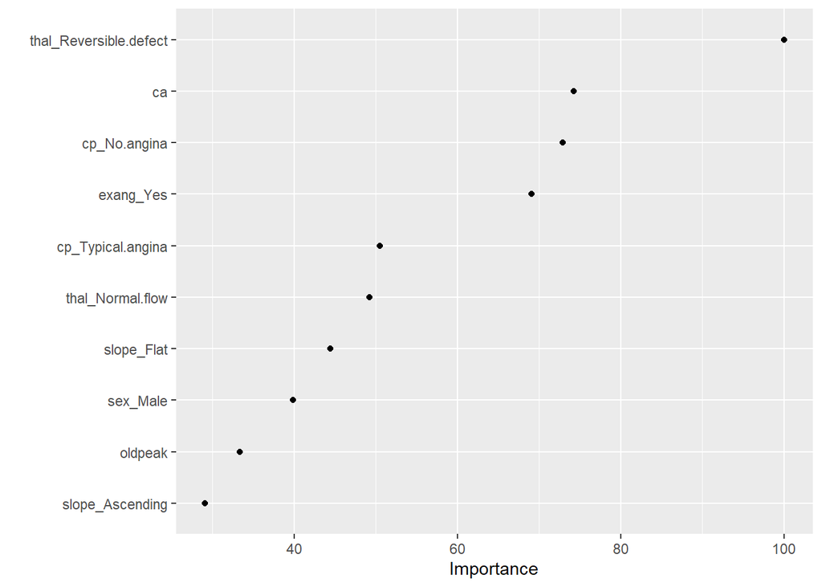

```r
library(vip)
vip(modelo_glm,geom = "point")
```

The object returned by train () contains multiple elements and a lot of information. At the moment, $ finalModel is analyzed, which is the final model obtained after the adjustment.

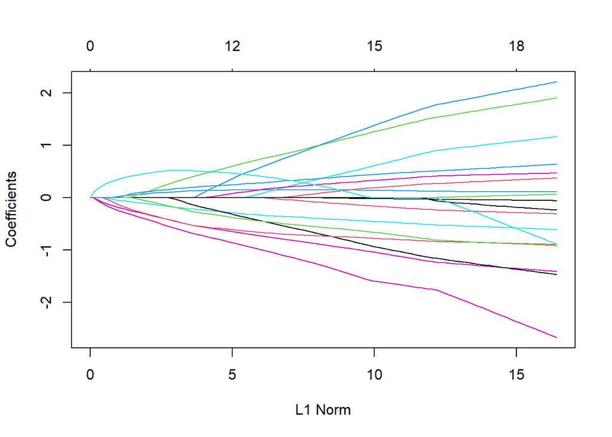

```r
plot(modelo_glm$finalModel)
```

```r
View(modelo_glm$resample)
```

[glmnet help](https://web.stanford.edu/~hastie/glmnet/glmnet_alpha.html)

## 7.3 Resample

```r
summary(modelo_glm$resample$Accuracy)
```

```
##    Min. 1st Qu.  Median    Mean 3rd Qu.    Max.
##  0.7959  0.8367  0.8542  0.8511  0.8750  0.8958
```

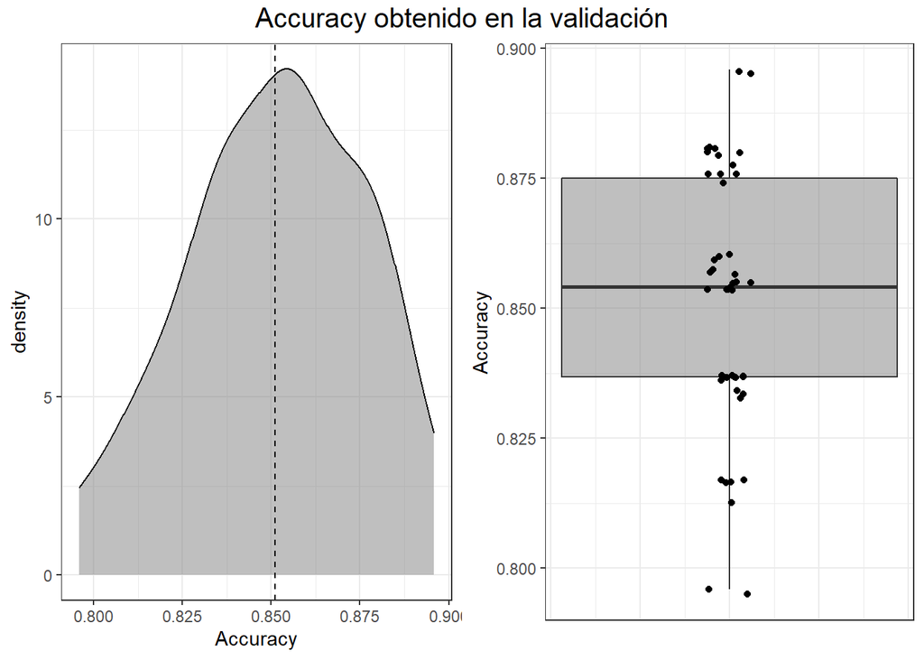

```r
p1 <- ggplot(data = modelo_glm$resample, aes(x = Accuracy)) +
      geom_density(alpha = 0.5, fill = "gray50") +
      geom_vline(xintercept = mean(modelo_glm$resample$Accuracy),
                 linetype = "dashed") +
      theme_bw()
p2 <- ggplot(data = modelo_glm$resample, aes(x = 1, y = Accuracy)) +
      geom_boxplot(outlier.shape = NA, alpha = 0.5, fill = "gray50") +
      geom_jitter(width = 0.05) +
      labs(x = "") +
      theme_bw() +
      theme(axis.text.x = element_blank(), axis.ticks.x = element_blank())

final_plot <- ggarrange(p1, p2)
final_plot <- annotate_figure(
                final_plot,
                top = text_grob("Accuracy obtenido en la validación", size = 15))
final_plot
```

## 7.4 Hyperparameter optimization

## 7.5 Other models

```r
# Usage
# st <- Sys.time()
# progressTime(st)


progressTime <- function(T.start, T.end=0){
  if(T.end==0) {T.end <- Sys.time()}
  T.end - T.start
  cat("Summary\n")
  cat("\tStart:\t", format(T.start), "\n")
  cat("\tEnd:\t", format(T.end), "\n\t")
  print(T.end - T.start)

}
```

```r
set.seed(123)

control_train <- trainControl(method = "cv",
                        number = 5,
                        returnResamp="all",
                        classProbs =T)

hiperparametros <- data.frame(C = c(0.001, 0.01, 0.1, 0.5, 1, 10))

st <- Sys.time()
modelo_svm <- train(target ~ ., data = datos_train_prep,
                    method = "svmLinear",
                    tuneGrid = hiperparametros,
                    trControl  = control_train,
                    metric = "Accuracy")
progressTime(st)
```

```
## Summary
##  Start:   2021-02-25 11:43:33
##  End:     2021-02-25 11:43:36
##  Time difference of 2.467818 secs
```

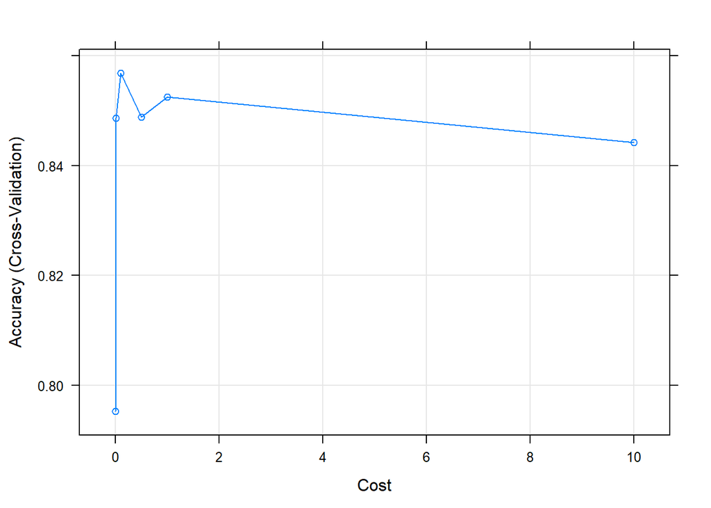

```r
plot(modelo_svm)
```

```r
modelo_svm$results
```

|  | C | Accuracy | Kappa | AccuracySD | KappaSD |
| --- | --- | --- | --- | --- | --- |
| 1 | 1e-03 | 0.7952007 | 0.5971647 | 0.03792156 | 0.07291830 |
| 2 | 1e-02 | 0.8486156 | 0.6929966 | 0.04145732 | 0.08564363 |
| 3 | 1e-01 | 0.8568605 | 0.7101117 | 0.02712147 | 0.05587825 |
| 4 | 5e-01 | 0.8487789 | 0.6920910 | 0.03510025 | 0.07448715 |
| 5 | 1e+00 | 0.8525272 | 0.6995923 | 0.02176781 | 0.04883734 |
| 6 | 1e+01 | 0.8441939 | 0.6829076 | 0.01878501 | 0.04124047 |

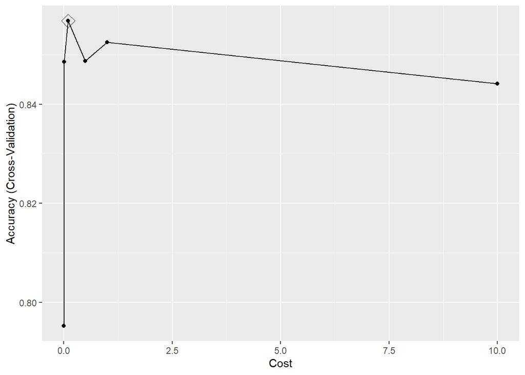

```r
ggplot(modelo_svm, highlight = TRUE)
```

```r
modelo_svm
```

```
## Support Vector Machines with Linear Kernel
##
## 244 samples
##  18 predictor
##   2 classes: 'Yes', 'No'
##
## No pre-processing
## Resampling: Cross-Validated (5 fold)
## Summary of sample sizes: 195, 196, 194, 196, 195
## Resampling results across tuning parameters:
##
##   C      Accuracy   Kappa
##   1e-03  0.7952007  0.5971647
##   1e-02  0.8486156  0.6929966
##   1e-01  0.8568605  0.7101117
##   5e-01  0.8487789  0.6920910
##   1e+00  0.8525272  0.6995923
##   1e+01  0.8441939  0.6829076
##
## Accuracy was used to select the optimal model using the largest value.
## The final value used for the model was C = 0.1.
```

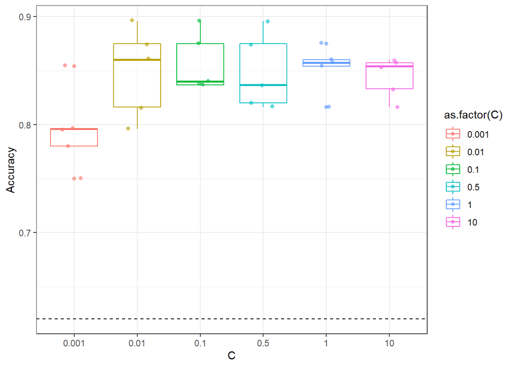

```r
ggplot(data = modelo_svm$resample,
       aes(x = as.factor(C), y = Accuracy, color = as.factor(C))) +
  geom_boxplot(alpha = 0.6) +
  geom_jitter(width = 0.2, alpha = 0.6) +
  # Línea horizontal en el accuracy basal
  geom_hline(yintercept = 0.62, linetype = "dashed") +
  labs(x = "C") +
  theme_bw()
```

> Your turn: find the best hyperparameters for a random forest, measuring Accuracy with a repeated CV (folds = 5, repeats = 5)

> find the best hyperparameters for a elasticnet logistic regression (glmnet), measuring Accuracy with a repeated CV (folds = 5, repeats = 10)

```r
# try to change it to oob
# control_train <- trainControl(method = "cv",number = 5,
#                               returnResamp = "all",
#                               verboseIter = TRUE)

hiperparametros <- data.frame(mtry = 1:18)


st <- Sys.time()


modelo_rf <- train(target ~ ., data = datos_train_prep,
                    method = "rf",
                    trControl  = control_train,
                   tuneGrid = hiperparametros,
                    metric = "Accuracy")
progressTime(st)
```

```
## Summary
##  Start:   2021-02-25 11:43:37
##  End:     2021-02-25 11:43:48
##  Time difference of 11.43746 secs
```

```r
modelo_rf$bestTune
```

|  | mtry |
| --- | --- |
| 2 | 2 |

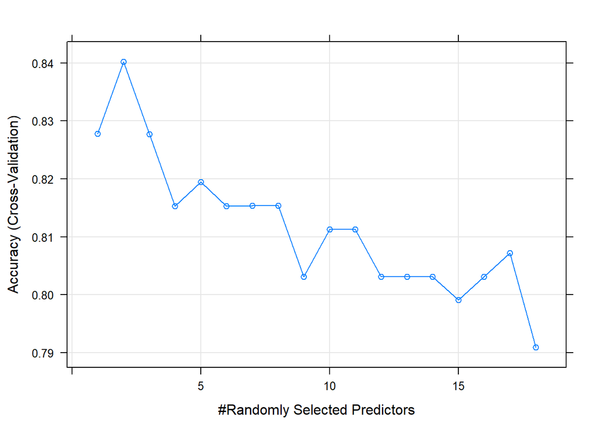

```r
plot(modelo_rf)
```

```r
confMat(modelo_rf)
```

```
## Confusion Matrix and Statistics
##
##           Reference
## Prediction Yes No
##        Yes  23  9
##        No    4 23
##
##                Accuracy : 0.7797
##                  95% CI : (0.6527, 0.8771)
##     No Information Rate : 0.5424
##     P-Value [Acc > NIR] : 0.0001366
##
##                   Kappa : 0.5625
##
##  Mcnemar's Test P-Value : 0.2672575
##
##             Sensitivity : 0.8519
##             Specificity : 0.7188
##          Pos Pred Value : 0.7188
##          Neg Pred Value : 0.8519
##              Prevalence : 0.4576
##          Detection Rate : 0.3898
##    Detection Prevalence : 0.5424
##       Balanced Accuracy : 0.7853
##
##        'Positive' Class : Yes
##
```

Accuracy : 0.7797

```r
modelo_rf
```

```
## Random Forest
##
## 244 samples
##  18 predictor
##   2 classes: 'Yes', 'No'
##
## No pre-processing
## Resampling: Cross-Validated (5 fold)
## Summary of sample sizes: 195, 195, 195, 195, 196
## Resampling results across tuning parameters:
##
##   mtry  Accuracy   Kappa
##    1    0.8278061  0.6493570
##    2    0.8402211  0.6765754
##    3    0.8277211  0.6513037
##    4    0.8153061  0.6256498
##    5    0.8194728  0.6340879
##    6    0.8153061  0.6263517
##    7    0.8153912  0.6265604
##    8    0.8153912  0.6273016
##    9    0.8031463  0.6022490
##   10    0.8113095  0.6186689
##   11    0.8113095  0.6184874
##   12    0.8031463  0.6020305
##   13    0.8031463  0.6020305
##   14    0.8031463  0.6019578
##   15    0.7990646  0.5947893
##   16    0.8031463  0.6017763
##   17    0.8072279  0.6104823
##   18    0.7909014  0.5775215
##
## Accuracy was used to select the optimal model using the largest value.
## The final value used for the model was mtry = 2.
```

```r
set.seed(123)


st <- Sys.time()

modelo_ada <- train(target ~ ., data = datos_train_prep,
                    method = "adaboost",
                    trControl  = control_train,
                    metric = "Accuracy")
progressTime(st)
```

```
## Summary
##  Start:   2021-02-25 11:43:48
##  End:     2021-02-25 11:44:23
##  Time difference of 34.24936 secs
```

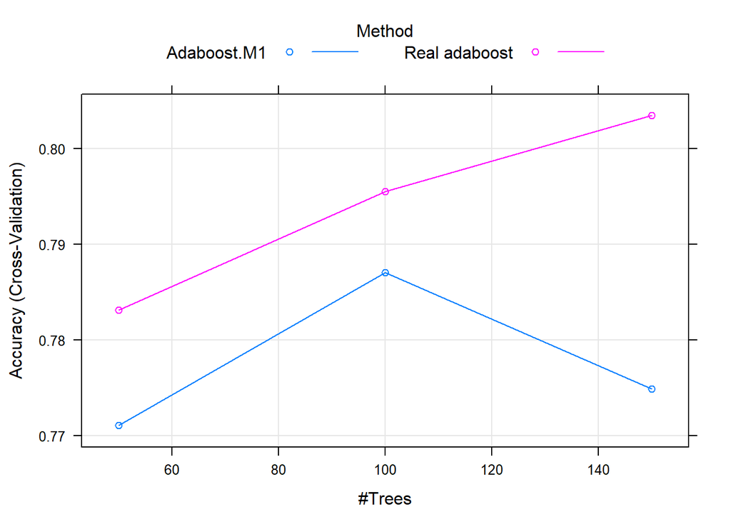

```r
plot(modelo_ada)
```

```r
modelo_ada$bestTune
```

|  | nIter | method |
| --- | --- | --- |
| 6 | 150 | Real adaboost |

```r
View(modelo_ada$resample)
```

```r
modelo_ada
```

```
## AdaBoost Classification Trees
##
## 244 samples
##  18 predictor
##   2 classes: 'Yes', 'No'
##
## No pre-processing
## Resampling: Cross-Validated (5 fold)
## Summary of sample sizes: 195, 196, 194, 196, 195
## Resampling results across tuning parameters:
##
##   nIter  method         Accuracy   Kappa
##    50    Adaboost.M1    0.7710442  0.5369368
##    50    Real adaboost  0.7831293  0.5599452
##   100    Adaboost.M1    0.7870408  0.5701230
##   100    Real adaboost  0.7955408  0.5833695
##   150    Adaboost.M1    0.7748776  0.5455769
##   150    Real adaboost  0.8034558  0.6013715
##
## Accuracy was used to select the optimal model using the largest value.
## The final values used for the model were nIter = 150 and method = Real adaboost.
```

## 7.6 RandomForest

Adjustment, optimization and validation of the model

The ranger caret method uses the ranger () function of the ranger package. This algorithm has 3 hyperparameters:

- mtry: number of randomly selected predictors in each tree.
- min.node.size: minimum size that a node must have in order to be divided.
- splitrule: split criteria.

Although caret also includes the rf method with the rf () function of the randomForest package, the latter only allows optimizing the mtry hyperparameter.

```r
# Hiperparámetros
hiperparametros <- expand.grid(mtry = c(3, 4, 5, 7),
                               min.node.size = c(2, 3, 4, 5, 10, 15, 20, 30),
                               splitrule = "gini")



# AJUSTE DEL MODELO
# ==============================================================================
set.seed(123)
modelo_rf2 <- train(target ~ ., data = datos_train_prep,
                   method = "ranger",
                   tuneGrid = hiperparametros,
                   metric = "Accuracy",
                   trControl = control_train,
                   # Número de árboles ajustados
                   num.trees = 500)
modelo_rf2
```

```
## Random Forest
##
## 244 samples
##  18 predictor
##   2 classes: 'Yes', 'No'
##
## No pre-processing
## Resampling: Cross-Validated (5 fold)
## Summary of sample sizes: 195, 196, 194, 196, 195
## Resampling results across tuning parameters:
##
##   mtry  min.node.size  Accuracy   Kappa
##   3      2             0.8201156  0.6359114
##   3      3             0.8241156  0.6452138
##   3      4             0.8243673  0.6433164
```

[output cut: 34 more lines]

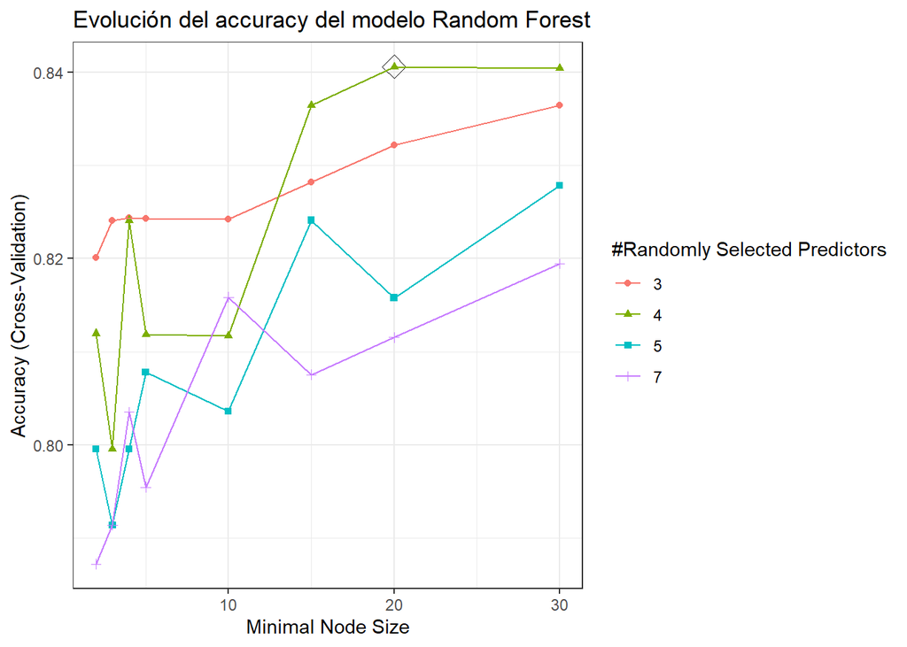

```r
ggplot(modelo_rf2, highlight = TRUE) +  theme_bw() +   labs(title = "Evolución del accuracy del modelo Random Forest")
```

```r
confMat(modelo_rf)
```

```
## Confusion Matrix and Statistics
##
##           Reference
## Prediction Yes No
##        Yes  23  9
##        No    4 23
##
##                Accuracy : 0.7797
##                  95% CI : (0.6527, 0.8771)
##     No Information Rate : 0.5424
##     P-Value [Acc > NIR] : 0.0001366
##
##                   Kappa : 0.5625
##
##  Mcnemar's Test P-Value : 0.2672575
##
##             Sensitivity : 0.8519
##             Specificity : 0.7188
##          Pos Pred Value : 0.7188
##          Neg Pred Value : 0.8519
##              Prevalence : 0.4576
##          Detection Rate : 0.3898
##    Detection Prevalence : 0.5424
##       Balanced Accuracy : 0.7853
##
##        'Positive' Class : Yes
##
```

```r
modelo_rf$bestTune
```

|  | mtry |
| --- | --- |
| 2 | 2 |

Accuracy : 0.7797

```r
modelo_rf
```

```
## Random Forest
##
## 244 samples
##  18 predictor
##   2 classes: 'Yes', 'No'
##
## No pre-processing
## Resampling: Cross-Validated (5 fold)
## Summary of sample sizes: 195, 195, 195, 195, 196
## Resampling results across tuning parameters:
##
##   mtry  Accuracy   Kappa
##    1    0.8278061  0.6493570
##    2    0.8402211  0.6765754
##    3    0.8277211  0.6513037
##    4    0.8153061  0.6256498
##    5    0.8194728  0.6340879
##    6    0.8153061  0.6263517
##    7    0.8153912  0.6265604
##    8    0.8153912  0.6273016
##    9    0.8031463  0.6022490
##   10    0.8113095  0.6186689
##   11    0.8113095  0.6184874
##   12    0.8031463  0.6020305
##   13    0.8031463  0.6020305
##   14    0.8031463  0.6019578
##   15    0.7990646  0.5947893
##   16    0.8031463  0.6017763
##   17    0.8072279  0.6104823
##   18    0.7909014  0.5775215
##
## Accuracy was used to select the optimal model using the largest value.
## The final value used for the model was mtry = 2.
```

# 8 Compare models

```r
modelos <- list(GLM = modelo_glm,  RF = modelo_rf, SVM = modelo_svm, ADA = modelo_ada)

resultados_resamples <- resamples(modelos)
resultados_resamples$values
```

| Resample | GLM~Accuracy | GLM~Kappa | RF~Accuracy | RF~Kappa | SVM~Accuracy | SVM~Kappa | ADA~Accuracy | ADA~Kappa |
| --- | --- | --- | --- | --- | --- | --- | --- | --- |
| Fold1 | 0.8775510 | 0.7482877 | 0.8367347 | 0.6672326 | 0.8367347 | 0.6614853 | 0.7755102 | 0.5325239 |
| Fold2 | 0.8541667 | 0.7073171 | 0.8571429 | 0.7100592 | 0.8958333 | 0.7894737 | 0.8333333 | 0.6643357 |
| Fold3 | 0.8800000 | 0.7553018 | 0.8571429 | 0.7100592 | 0.8400000 | 0.6758509 | 0.8200000 | 0.6388443 |
| Fold4 | 0.8750000 | 0.7464789 | 0.7959184 | 0.5923461 | 0.8750000 | 0.7482517 | 0.8333333 | 0.6619718 |
| Fold5 | 0.8367347 | 0.6700337 | 0.8541667 | 0.7031802 | 0.8367347 | 0.6754967 | 0.7551020 | 0.5091820 |

> your turn: calculate median of accuracy

```r
metricas_resamples <- resultados_resamples$values %>%
                         gather(key = "modelo", value = "valor", -Resample) %>%
                         separate(col = "modelo", into = c("modelo", "metrica"),
                                  sep = "~", remove = TRUE)
metricas_resamples %>% head()
```

|  | Resample | modelo | metrica | valor |
| --- | --- | --- | --- | --- |
| 1 | Fold1 | GLM | Accuracy | 0.8775510 |
| 2 | Fold2 | GLM | Accuracy | 0.8541667 |
| 3 | Fold3 | GLM | Accuracy | 0.8800000 |
| 4 | Fold4 | GLM | Accuracy | 0.8750000 |
| 5 | Fold5 | GLM | Accuracy | 0.8367347 |
| 6 | Fold1 | GLM | Kappa | 0.7482877 |

```r
metricas_resamples %>%
  group_by(modelo, metrica) %>%
  summarise(media = mean(valor)) %>%
  spread(key = metrica, value = media) %>%
  arrange(desc(Accuracy))
```

| modelo | Accuracy | Kappa |
| --- | --- | --- |
| GLM | 0.8646905 | 0.7254838 |
| SVM | 0.8568605 | 0.7101117 |
| RF | 0.8402211 | 0.6765754 |
| ADA | 0.8034558 | 0.6013715 |

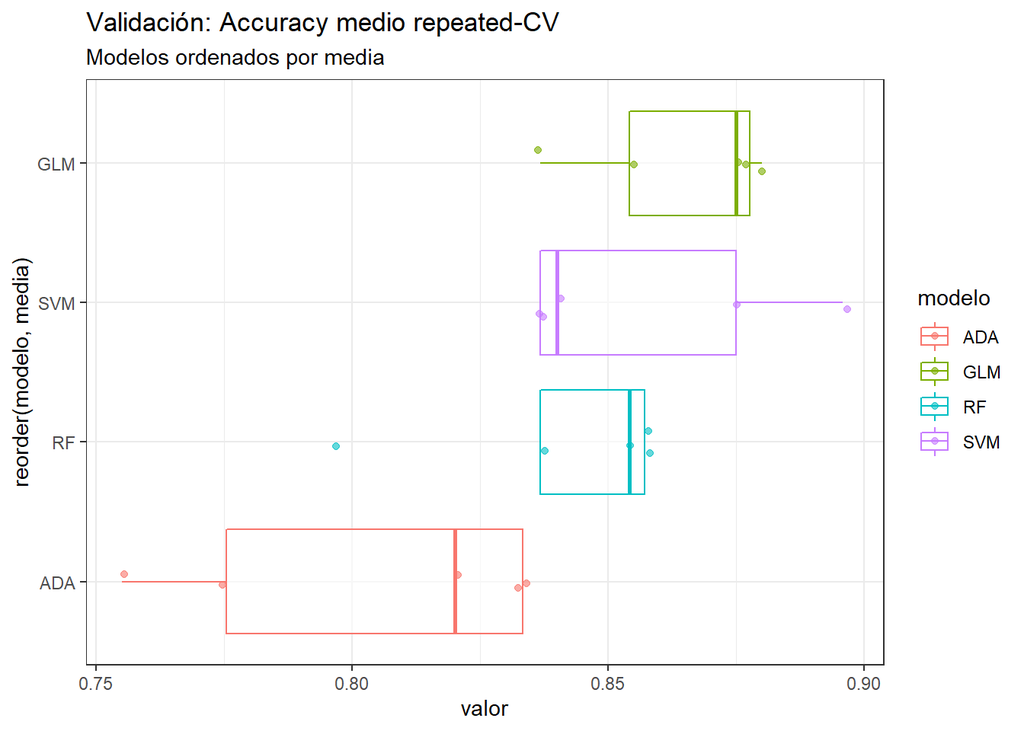

```r
metricas_resamples %>% filter(metrica == "Accuracy") %>%
  group_by(modelo) %>%
  mutate(media = mean(valor)) %>%
  ungroup() %>%
  ggplot(aes(x = reorder(modelo, media), y = valor, color = modelo)) +
    geom_boxplot(alpha = 0.6, outlier.shape = NA) +
    geom_jitter(width = 0.1, alpha = 0.6) +
    theme_bw() +
    labs(title = "Validación: Accuracy medio repeated-CV",
         subtitle = "Modelos ordenados por media") +
    coord_flip()
```

# 9 Supplementary

## 9.1 Using ROC curve

```r
control_train <- trainControl(method="cv", number=5, returnResamp="all", classProbs=TRUE, summaryFunction=twoClassSummary, savePredictions = TRUE )

set.seed(123)
# Predictores: Survived, SibSp, Parch, Fare, Pclass_X2, Pclass_X3, Sex_male, Embarked_Q,
#              Embarked_S, Age_grupo_anciano, Age_grupo_niño
modelo_glm <- train(target ~ ., method = "glmnet", family = "binomial", data = datos_train_prep, trControl  = control_train, metric = "ROC")


modelo_glm
```

```
## glmnet
##
## 244 samples
##  18 predictor
##   2 classes: 'Yes', 'No'
##
## No pre-processing
## Resampling: Cross-Validated (5 fold)
## Summary of sample sizes: 195, 196, 194, 196, 195
## Resampling results across tuning parameters:
##
##   alpha  lambda        ROC        Sens       Spec
##   0.10   0.0005344187  0.9133008  0.8106719  0.8715100
##   0.10   0.0053441866  0.9177297  0.8197628  0.8717949
##   0.10   0.0534418657  0.9201919  0.8197628  0.8948718
##   0.55   0.0005344187  0.9129641  0.8106719  0.8789174
##   0.55   0.0053441866  0.9177314  0.8288538  0.8792023
##   0.55   0.0534418657  0.9203631  0.8110672  0.9094017
##   1.00   0.0005344187  0.9129641  0.8106719  0.8789174
##   1.00   0.0053441866  0.9204087  0.8288538  0.8715100
##   1.00   0.0534418657  0.9128993  0.7841897  0.8789174
##
## ROC was used to select the optimal model using the largest value.
## The final values used for the model were alpha = 1 and lambda = 0.005344187.
```

```r
library(MLeval)
## run MLeval

res <- evalm(modelo_glm)
```

```
## ***MLeval: Machine Learning Model Evaluation***
```

```
## Input: caret train function object
```

```
## Not averaging probs.
```

```
## Group 1 type: cv
```

```
## Observations: 244
```

```
## Number of groups: 1
```

```
## Observations per group: 244
```

```
## Positive: No
```

```
## Negative: Yes
```

```
## Group: Group 1
```

```
## Positive: 133
```

```
## Negative: 111
```

```
## ***Performance Metrics***
```

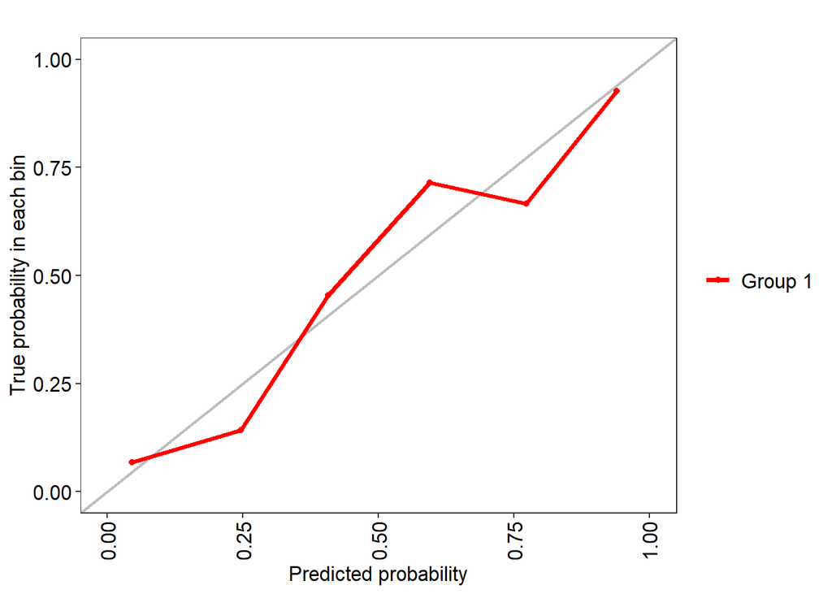

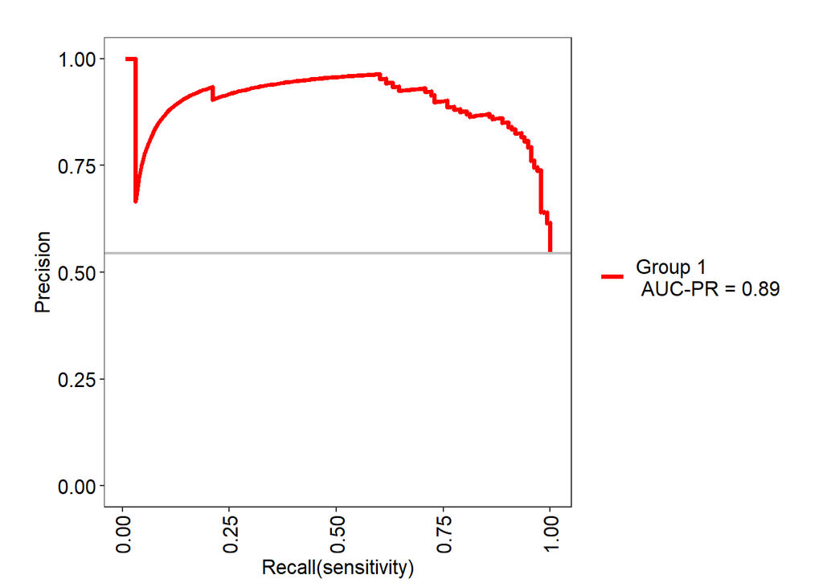

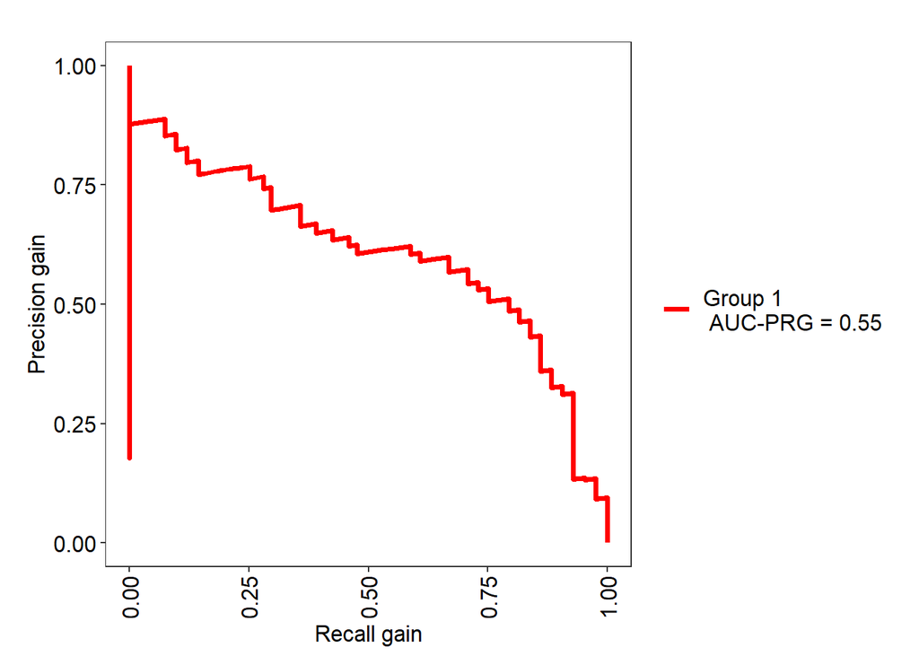

```
## Group 1 Optimal Informedness = 0.716046873941611
```

```
## Group 1 AUC-ROC = 0.92
```

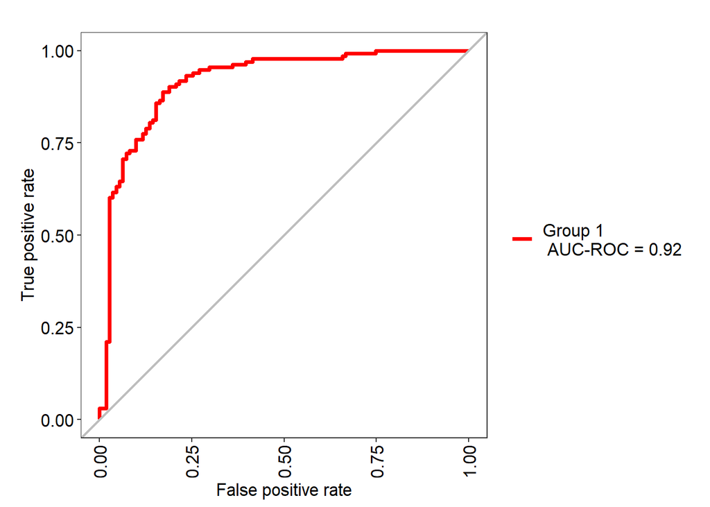

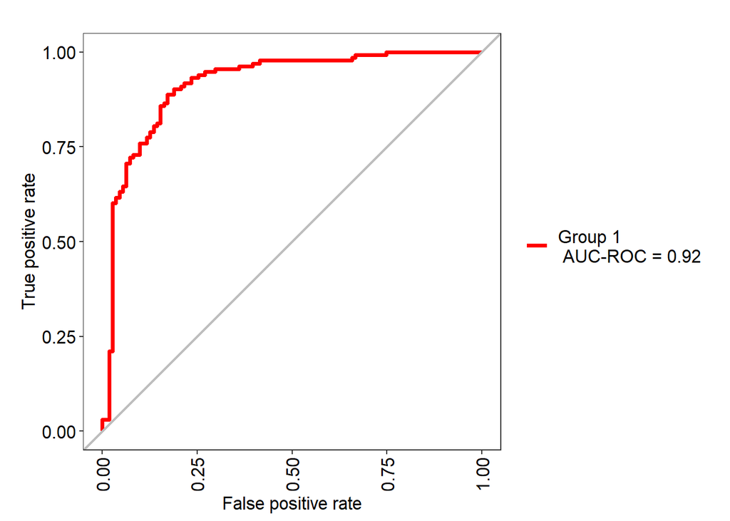

```r
## get ROC

res$roc
```

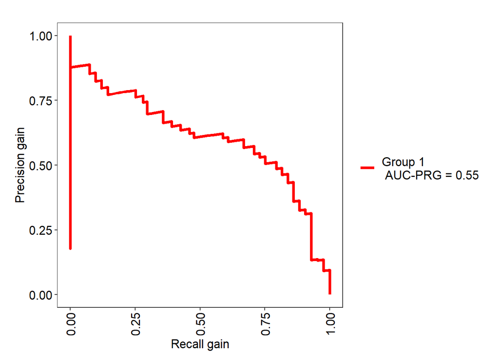

```r
## get precision recall gain curve

res$prg
```

# 10 Models

For this part I chose to build four models. Three simple ones: logistic regression, naïve bayes and decision trees. And one a bit more complex: random forest.

Null values where already dropped in a previous cell. Also, categorical variables have already been converted to R factors. Apart from this no more explicit preprocessing was done in this notebook to keep it simple and easy to follow.

The test set mimics data in the real world, it will only be used at the end of the project to get a more robust measure of the models on unseen data.

The training set will be used to evaluate the models via 10 fold cross-validation. For simplicity, we’ll leave the hypeparameter selection of the models by default, this means that some random combinations will be chosen and the models will be trained via cross-validation for each combination, keeping the hiperparameter combination that gave the best result.

## 10.1 Logistic regression

```r
# 10 fold Cross-validation
fitControl <- trainControl(method="cv", number=10)
set.seed(8)
model.lr <- train(target ~ .,
              data = datos_train_prep,
              method = "glmnet",
              family="binomial",
              trControl = fitControl)
model.lr
```

```
## glmnet
##
## 244 samples
##  18 predictor
##   2 classes: 'Yes', 'No'
##
## No pre-processing
## Resampling: Cross-Validated (10 fold)
## Summary of sample sizes: 219, 220, 220, 219, 220, 220, ...
## Resampling results across tuning parameters:
##
##   alpha  lambda        Accuracy   Kappa
##   0.10   0.0005344187  0.8523333  0.7011463
##   0.10   0.0053441866  0.8481667  0.6923158
##   0.10   0.0534418657  0.8563333  0.7081486
##   0.55   0.0005344187  0.8523333  0.7011463
##   0.55   0.0053441866  0.8480000  0.6921983
##   0.55   0.0534418657  0.8483333  0.6908860
##   1.00   0.0005344187  0.8523333  0.7011463
##   1.00   0.0053441866  0.8480000  0.6913723
##   1.00   0.0534418657  0.8403333  0.6760653
##
## Accuracy was used to select the optimal model using the largest value.
## The final values used for the model were alpha = 0.1 and lambda = 0.05344187.
```

## 10.2 Decision tree

```r
set.seed(8)
model.tree <- train(target ~ .,
              data = datos_train_prep,
              method = "rpart",
              trControl = fitControl)
model.tree
```

```
## CART
##
## 244 samples
##  18 predictor
##   2 classes: 'Yes', 'No'
##
## No pre-processing
## Resampling: Cross-Validated (10 fold)
## Summary of sample sizes: 219, 220, 220, 219, 220, 220, ...
## Resampling results across tuning parameters:
##
##   cp          Accuracy   Kappa
##   0.04054054  0.7135000  0.4222874
##   0.05405405  0.7301667  0.4554917
##   0.49549550  0.5808333  0.1021565
##
## Accuracy was used to select the optimal model using the largest value.
## The final value used for the model was cp = 0.05405405.
```

Looks like the tree was build for three different values of a `cp` hyperparameter. This comes from `rpart` and it is a hyperparameter that governs the complexity of the model: lower values give more complex (bigger) trees.

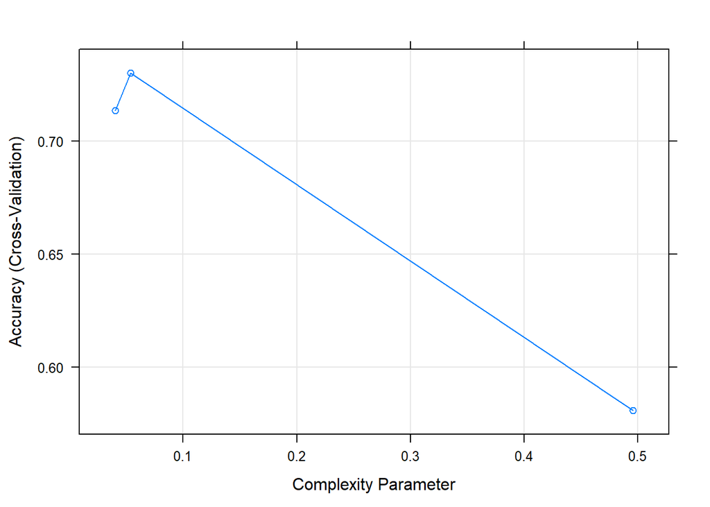

```r
plot(model.tree)
```

The results are acceptable and the tree is very small and easy to interpret as we can see below.

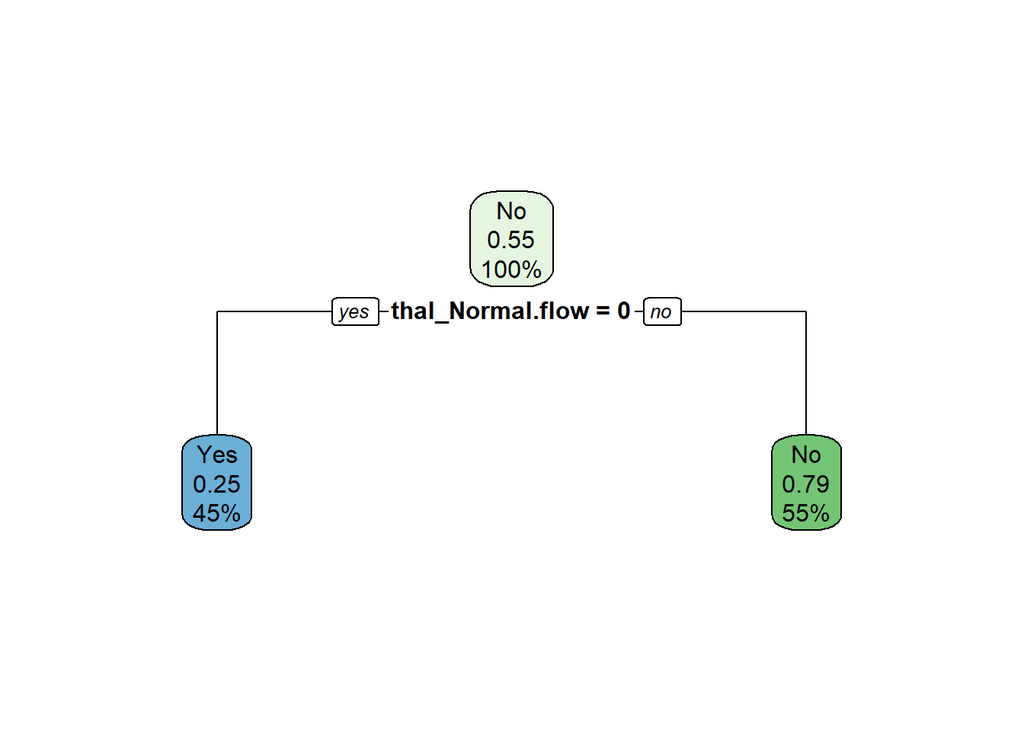

```r
rpart.plot(model.tree$finalModel)
```

## 10.3 Naive bayes

```r
set.seed(8)
model.nb <- train(target ~ .,
              data = datos_train_prep,
              method = "naive_bayes",
              trControl = fitControl)
model.nb
```

```
## Naive Bayes
##
## 244 samples
##  18 predictor
##   2 classes: 'Yes', 'No'
##
## No pre-processing
## Resampling: Cross-Validated (10 fold)
## Summary of sample sizes: 219, 220, 220, 219, 220, 220, ...
## Resampling results across tuning parameters:
##
##   usekernel  Accuracy   Kappa
##   FALSE      0.8443333  0.6819240
##    TRUE      0.8280000  0.6506756
##
## Tuning parameter 'laplace' was held constant at a value of 0
## Tuning
##  parameter 'adjust' was held constant at a value of 1
## Accuracy was used to select the optimal model using the largest value.
## The final values used for the model were laplace = 0, usekernel = FALSE
##  and adjust = 1.
```

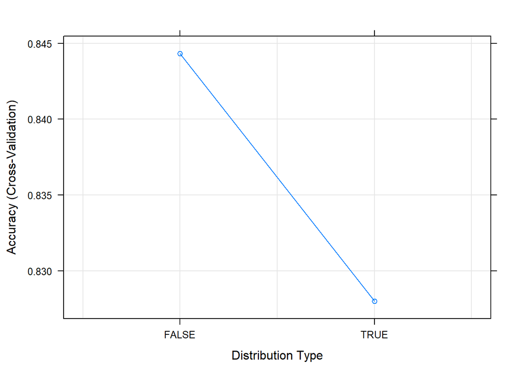

```r
plot(model.nb)
```

Also acceptable results

## 10.4 Random forest

```r
set.seed(8)
model.rf <- train(target ~ .,
              data = datos_train_prep,
              method = "rf",
              trControl = fitControl)
model.rf
```

```
## Random Forest
##
## 244 samples
##  18 predictor
##   2 classes: 'Yes', 'No'
##
## No pre-processing
## Resampling: Cross-Validated (10 fold)
## Summary of sample sizes: 219, 220, 220, 219, 220, 220, ...
## Resampling results across tuning parameters:
##
##   mtry  Accuracy   Kappa
##    2    0.8280000  0.6523275
##   10    0.7876667  0.5725029
##   18    0.7876667  0.5722444
##
## Accuracy was used to select the optimal model using the largest value.
## The final value used for the model was mtry = 2.
```

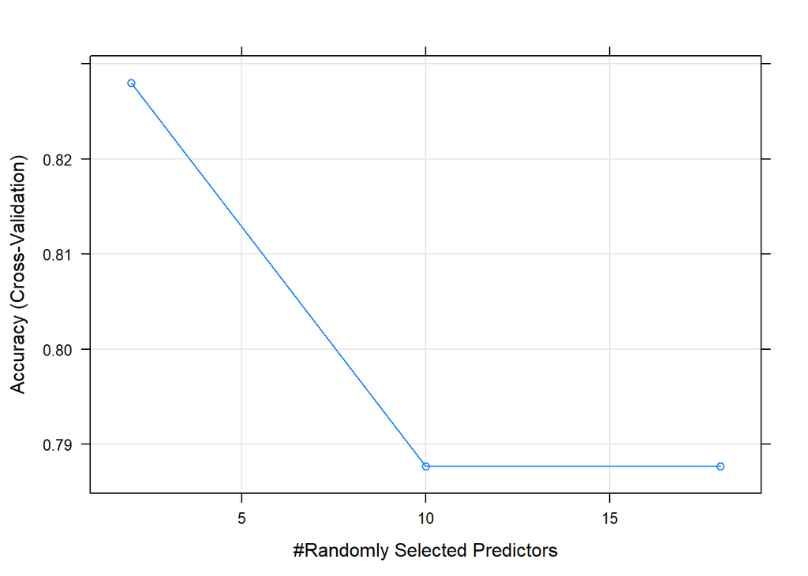

```r
plot(model.rf)
```

Interesting to see that logistic regression is still better. Maybe with a better hiperparameter tuning this model may get better results.

# 11 Results

## 11.1 Summary of the training

As for final results, we’ll see how logistic regression performs on the test set. And we’ll take the tree as an example to see that it doesn’t do a good job.

## 11.2 Final results

**Logistic regression:**

```r
preds <- predict(model.lr, datos_test_prep)
confusionMatrix(preds, datos_test_prep$target)
```

```
## Confusion Matrix and Statistics
##
##           Reference
## Prediction Yes No
##        Yes  22  6
##        No    5 26
##
##                Accuracy : 0.8136
##                  95% CI : (0.6909, 0.9031)
##     No Information Rate : 0.5424
##     P-Value [Acc > NIR] : 1.224e-05
##
##                   Kappa : 0.6255
##
##  Mcnemar's Test P-Value : 1
##
##             Sensitivity : 0.8148
##             Specificity : 0.8125
##          Pos Pred Value : 0.7857
##          Neg Pred Value : 0.8387
##              Prevalence : 0.4576
##          Detection Rate : 0.3729
##    Detection Prevalence : 0.4746
##       Balanced Accuracy : 0.8137
##
##        'Positive' Class : Yes
##
```

Good news, we have more or less the same results as in cross-validation. We also have a confusion matrix with most observations on the main diagonal.

```r
preds.tree <- predict(model.tree, datos_test_prep)
confusionMatrix(preds.tree, datos_test_prep$target)
```

```
## Confusion Matrix and Statistics
##
##           Reference
## Prediction Yes No
##        Yes  20  7
##        No    7 25
##
##                Accuracy : 0.7627
##                  95% CI : (0.6341, 0.8638)
##     No Information Rate : 0.5424
##     P-Value [Acc > NIR] : 0.0003962
##
##                   Kappa : 0.522
##
##  Mcnemar's Test P-Value : 1.0000000
##
##             Sensitivity : 0.7407
##             Specificity : 0.7812
##          Pos Pred Value : 0.7407
##          Neg Pred Value : 0.7812
##              Prevalence : 0.4576
##          Detection Rate : 0.3390
##    Detection Prevalence : 0.4576
##       Balanced Accuracy : 0.7610
##
##        'Positive' Class : Yes
##
```

# 12 Bibliography

In addition to the links provided throughout the notebook, the following resources where also consulted to better understand the topic:

- “Heart disease and heart attacks”. Khan Academy. Link: https://www.khanacademy.org/science/health-and-medicine/healthcare-misc/v/heart-disease-and-heart-attacks
- “Cellular respiration introduction”. Khan Academy. Link: https://www.khanacademy.org/science/biology/cellular-respiration-and-fermentation/intro-to-cellular-respiration/v/introduction-to-cellular-respiration
- “Enfermedades cardiovasculares”. Organización Mundial de la Salud. Link: https://www.who.int/es/news-room/fact-sheets/detail/cardiovascular-diseases-(cvds)
- “Heart Disease”. Mayo Clinic. Link: https://www.mayoclinic.org/diseases-conditions/heart-disease/symptoms-causes/syc-20353118
- “Coronary artery disease”. Mayo Clinic. Link: https://www.mayoclinic.org/diseases-conditions/coronary-artery-disease/symptoms-causes/syc-20350613
- “Heart Attack (Myocardial Infarction)”. Cleveland Clinic. Link: https://my.clevelandclinic.org/health/diseases/16818-heart-attack-myocardial-infarction
- “Coronary Artery Disease”. Cleveland Clinic. Link: https://my.clevelandclinic.org/health/diseases/16898-coronary-artery-disease
- Institute of Medicine (US) Committee on Social Security Cardiovascular Disability Criteria. Cardiovascular Disability: Updating the Social Security Listings. Washington (DC): National Academies Press (US); 2010. 7, Ischemic Heart Disease. Available from: https://www.ncbi.nlm.nih.gov/books/NBK209964/

Hope this was helpful, feel free to give an upvote if you like it. Also, if I made any mistake or if you have any question feel free to write it in the comments 🙂